# Prognozowanie ryzyka zawału serca na podstawie parametrów morfologii krwi

Julia Kołat

# Opis projektu

Projekt został zrealizowany w ramach studiów i koncentruje się na analizie ryzyka wystąpienia zawału serca (AMI – Acute Myocardial Infarction) z wykorzystaniem zaawansowanych metod statystycznych oraz algorytmów uczenia maszynowego. Głównym celem pracy było stworzenie modelu klasyfikacyjnego, który na podstawie rutynowych badań krwi potrafi z wysoką dokładnością odróżnić osoby zdrowe od pacjentów po zawale. Takie rozwiązanie mogłoby w przyszłości wspierać personel medyczny w szybszym prognozowaniu i diagnozowaniu incydentów kardiologicznych na oddziałach ratunkowych.

# 1. Dane

Baza danych użytych w tym projekcie pochodzi ze strony https://data.mendeley.com/datasets/m482gb564t/1.

Składa się z 981 obserwacji, które odpowiadają 477 pacjentom po zawale serca i 504 osobom, u których nie wykryto zawału serca. Dane zbierano od stycznia 2020 do maja 2023, od osób, które trafiły na oddział kardiologiczny i spełniły kryteria Europejskiego Towarzystwa Kardiologicznego m.in. miały więcej niż 18 lat, nie cierpiały na przewlekłe infekcje, nie wykryto u nich nowotworu. Wiek i płeć pacjentów pozyskano z dokumentacji medycznej, natomiast wyniki badań krwi pochodzą z pierwszego badania po przybyciu na oddział ratunkowy.

Baza danych składa się z następujących zmiennych:

- zmienna objaśniana: – AMI: zawał serca; 0 dla osoby zdrowej, 1 dla osoby po zawale serca;
- zmienne objaśniające: – SEX: płeć; 1 dla mężczyzny, 0 dla kobiety; – AGE: wiek; – WBC: white blood cell - białe krwinki; – RBC: red blood cell - czerwone krwinki; – HGB: hemoglobin - hemoglobina; – LY: lymphocyte - limfocyty; – MO: monocytes - monocyty.

Celem jest jak najlepsze zaklasyfikowanie osób po zawale serca na podstawie badań krwi, co mogłoby w przyszłości pomóc w prognozowaniu zawału.

# 2. Analiza

Przejdźmy do analizy zbioru danych. Po wczytaniu danych, zmienne AMI oraz SEX z liczbowych zmieniamy na factor.

```r
#uporzadkowanie danych
dane <- read.csv("Baza danych.csv")
dane[,1] <- as.factor(dane[,1])
dane[,2] <- as.factor(dane[,2])
```

Za pomocą funkcji summary sprawdzamy, czy nie występują obserwacje odstające.

```r
summary(dane)
```

```
##  AMI     SEX          AGE             WBC              RBC
##  0:504   0:413   Min.   :20.00   Min.   : 3.000   Min.   :2.700
##  1:477   1:568   1st Qu.:51.00   1st Qu.: 6.980   1st Qu.:4.380
##                  Median :60.00   Median : 8.500   Median :4.750
##                  Mean   :59.17   Mean   : 9.091   Mean   :4.755
##                  3rd Qu.:67.00   3rd Qu.:10.520   3rd Qu.:5.140
##                  Max.   :82.00   Max.   :30.900   Max.   :7.220
##       HGB              LY              MO
##  Min.   :10.08   Min.   :0.400   Min.   :0.0400
##  1st Qu.:12.60   1st Qu.:1.800   1st Qu.:0.4900
##  Median :13.70   Median :2.290   Median :0.6000
##  Mean   :13.75   Mean   :2.491   Mean   :0.6599
##  3rd Qu.:14.90   3rd Qu.:2.920   3rd Qu.:0.7800
##  Max.   :17.89   Max.   :9.000   Max.   :1.9000
```

Następnie, tworzymy wykresy punktowe dla kazdej zmiennej.

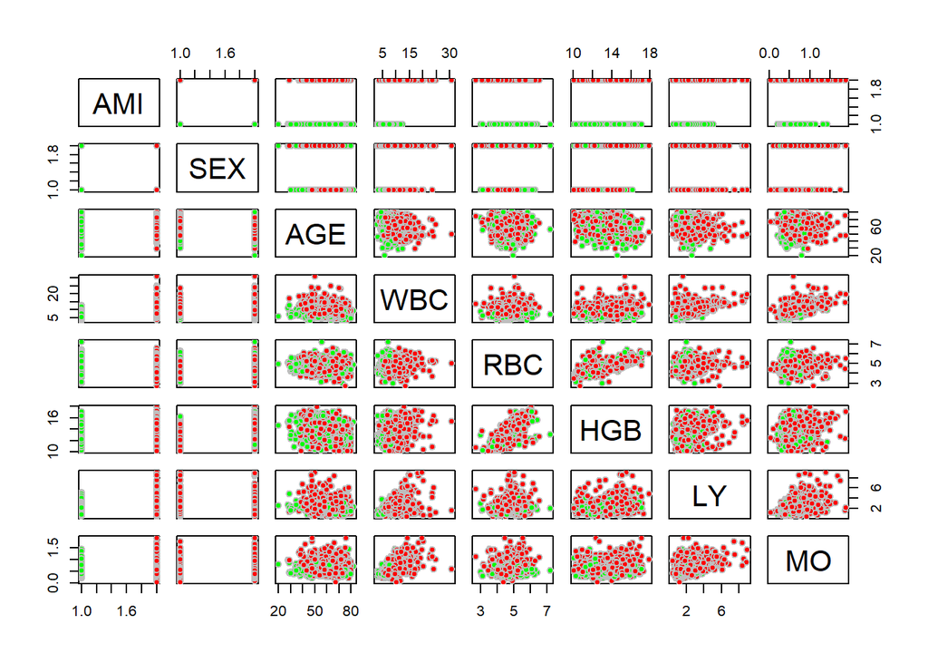

```r
#tworzymy wykresy punktowe dla wszystkich par zmiennych
lookup <- c('0'  = 'green', '1' = 'red')
col.ind <- lookup[dane$AMI]
pairs(dane, pch = 21, col = "gray", bg = col.ind)
```

Widzimy, ze wykres RBC/HGB jest zbliżony do liniowego, pozostałe przedstawiaja chmury punktów.

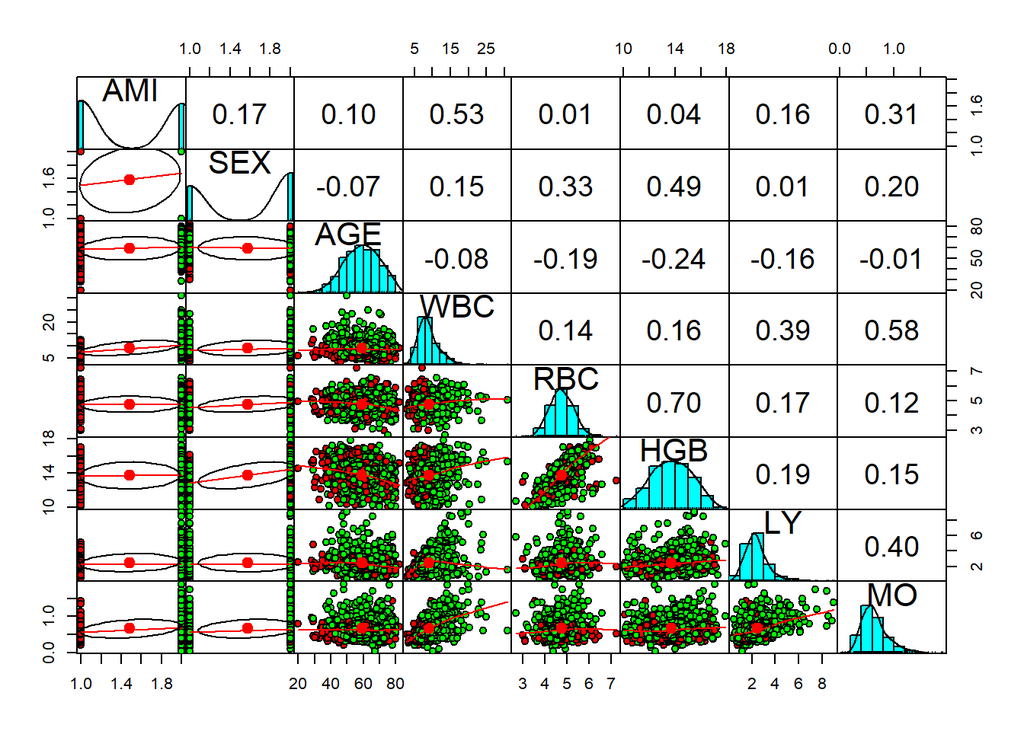

```r
pairs.panels(dane,
             gap = 0,
             bg = c("red", "green")[dane$AMI],
             pch = 21)
```

Gdy przeanalizujemy macierz korelacji, to możemy zauważyć, że największy współczynniki korelacji równy 0, 7 jest dla zmiennych RBC i HGB. Pozostałe współczynniki korelacji są znacząco mniejsze, co oznacza, że nie występuje zależność liniowa między zmiennymi.

```r
#tworzymy macierz korelacji
cor(dane[,3:8])
```

```
##              AGE         WBC        RBC        HGB         LY           MO
## AGE  1.000000000 -0.07511903 -0.1876835 -0.2427772 -0.1571656 -0.005955068
## WBC -0.075119031  1.00000000  0.1373904  0.1630527  0.3906219  0.582122525
## RBC -0.187683539  0.13739040  1.0000000  0.7043979  0.1707515  0.117027174
## HGB -0.242777158  0.16305265  0.7043979  1.0000000  0.1902762  0.149188373
## LY  -0.157165574  0.39062191  0.1707515  0.1902762  1.0000000  0.400655786
## MO  -0.005955068  0.58212252  0.1170272  0.1491884  0.4006558  1.000000000
```

Dzielimy nasze dane na zbiór uczący i zbiór testowy.

```r
#tworzymy zbiór uczący
set.seed(4)
train_sample<- sample(981,819)
test <- dane[-train_sample,]
train <-dane[train_sample,]

#sprawdzenie
prop.table(table(dane$AMI))
```

```
##
##         0         1
## 0.5137615 0.4862385
```

```r
prop.table(table(test$AMI))
```

```
##
##         0         1
## 0.5061728 0.4938272
```

```r
prop.table(table(train$AMI))
```

```
##
##         0         1
## 0.5152625 0.4847375
```

# 3. Modele

Teraz zajmiemy się budowaniem modeli w celu prognozowania zbioru testowego.

## 3.1. LDA

Pierwszym modelem jest *linear discriminant analysis*. Budujemy model. Jak pokazuje poniższy wykres, te dwie gęstości nachodzą na siebie, więc istnieje niepewność do której klasy zakwalifikować obserwacje.

```r
#LDA
lda.fit <- lda(AMI ~ . , data = train)
lda.fit
```

```
## Call:
## lda(AMI ~ ., data = train)
##
## Prior probabilities of groups:
##         0         1
## 0.5152625 0.4847375
##
## Group means:
##        SEX1      AGE       WBC      RBC      HGB       LY        MO
## 0 0.5071090 58.36730  7.464223 4.755995 13.70002 2.303294 0.5809242
## 1 0.6599496 60.42317 10.828060 4.763375 13.80529 2.681247 0.7435390
##
## Coefficients of linear discriminants:
##               LD1
## SEX1  0.561179979
## AGE   0.024224858
## WBC   0.361024786
## RBC  -0.173085270
## HGB  -0.066587525
## LY   -0.005070831
## MO   -0.056097161
```

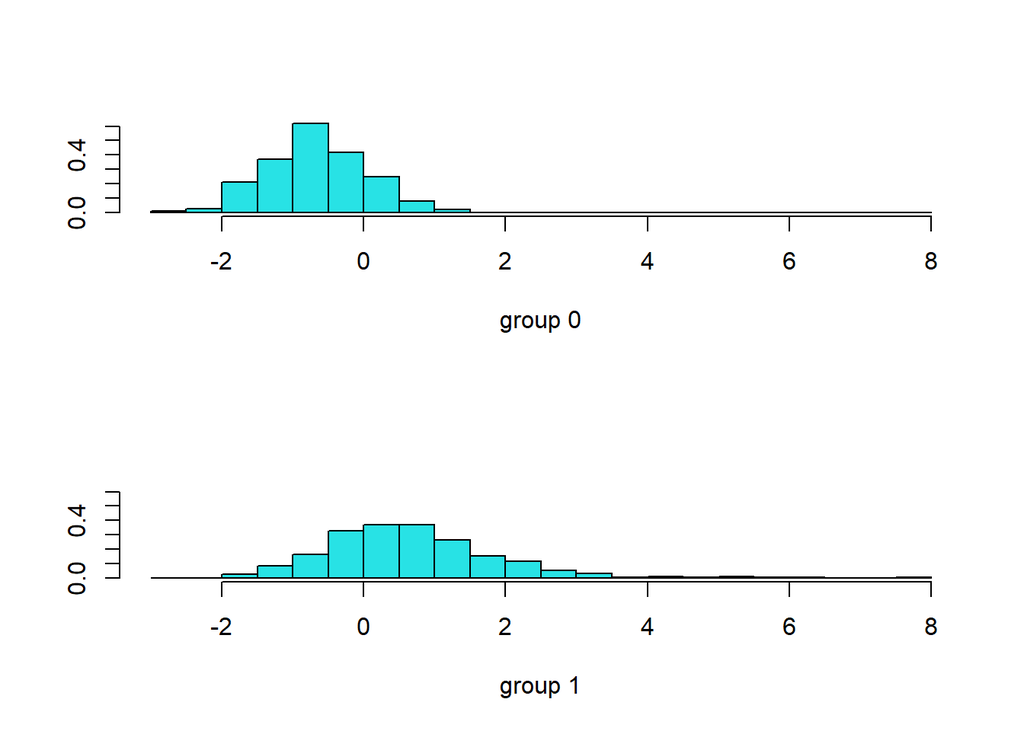

```r
#wykres gęstości
plot(lda.fit)
```

```r
lda.pred <- predict(lda.fit, test)
lda.class <- lda.pred$class
```

Tworzymy tablicę kontyngencji, która wygląda następująco:

```r
#tablica kontyngencji
table(lda.class, test$AMI)
```

```
##
## lda.class  0  1
##         0 74 27
##         1  8 53
```

```r
#dokładność modelu
mean(lda.class == test$AMI)
```

```
## [1] 0.7839506
```

Interpretacja:

Następnie obliczamy dokładność modelu, która wynosi 0.7840. Tworzymy krzywą ROC.

```r
# ROC
# Uzyskiwanie prawdopodobieństw dla klasy "1" (pozytywnej)
lda.prob <- lda.pred$posterior[, 2]
dane.test.num <- as.numeric(as.character(test$AMI))
# Dane do wykresu
roc_obj <- roc(dane.test.num, lda.prob)
```

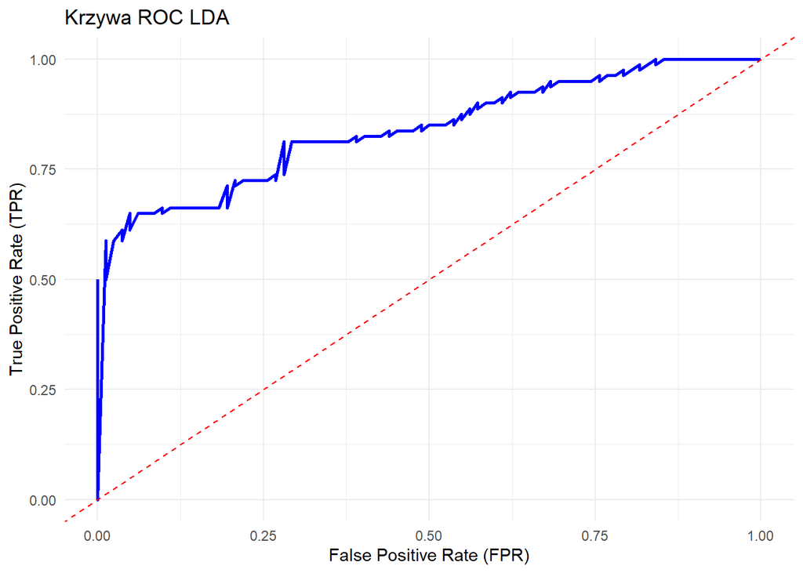

```r
roc_data <- data.frame(
  TPR = roc_obj$sensitivities,   # True Positive Rate
  FPR = 1 - roc_obj$specificities # False Positive Rate
)

# Rysowanie wykresu
ggplot(roc_data, aes(x = FPR, y = TPR)) +
  geom_line(color = "blue", linewidth = 1) +
  geom_abline(linetype = "dashed", color = "red") +
  labs(title = "Krzywa ROC LDA", x = "False Positive Rate (FPR)", y = "True Positive Rate (TPR)") +
  theme_minimal()
```

Obliczamy AUC (pole pod wykresem ROC LDA):

```r
# Obliczenie AUC
auc_value_LDA <- auc(roc_obj)
print(paste("AUC (pole pod wykresem ROC LDA):", auc_value_LDA))
```

```
## [1] "AUC (pole pod wykresem ROC LDA): 0.841615853658537"
```

## 3.2. QDA

Kolejnym modelem jest *quadratic discriminant analysis*.

```r
#QDA
qda.fit <- qda(AMI ~ ., data = train)
qda.fit
```

```
## Call:
## qda(AMI ~ ., data = train)
##
## Prior probabilities of groups:
##         0         1
## 0.5152625 0.4847375
##
## Group means:
##        SEX1      AGE       WBC      RBC      HGB       LY        MO
## 0 0.5071090 58.36730  7.464223 4.755995 13.70002 2.303294 0.5809242
## 1 0.6599496 60.42317 10.828060 4.763375 13.80529 2.681247 0.7435390
```

```r
qda.pred <- predict(qda.fit, test)
qda.class <- qda.pred$class
```

Budujemy model. Tworzymy tablicę kontyngencji.

```r
#tablica kontyngencji
table(qda.class, test$AMI)
```

```
##
## qda.class  0  1
##         0 75 29
##         1  7 51
```

```r
#dokładność modelu
mean(qda.class == test$AMI)
```

```
## [1] 0.7777778
```

Prawidłowo zakwalifikowano 126 obserwacji, a nieprawidłowo 36. Dokładność modelu wynosi: 0.7778. Tworzymy krzywą ROC.

```r
# ROC
# Uzyskiwanie prawdopodobieństw dla klasy "1" (pozytywnej)
qda.prob <- qda.pred$posterior[, 2]
dane.test.num <- as.numeric(as.character(test$AMI))
# Dane do wykresu
roc_obj <- roc( dane.test.num, qda.prob )
```

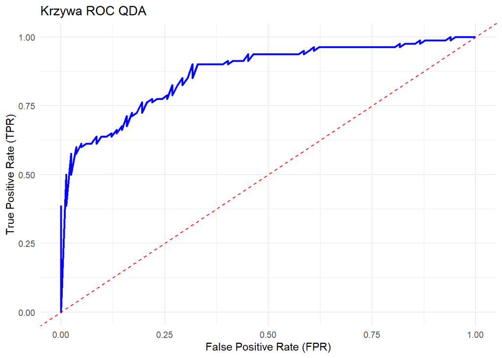

```r
roc_data <- data.frame(
  TPR = roc_obj$sensitivities,   # True Positive Rate
  FPR = 1 - roc_obj$specificities # False Positive Rate
)

# Rysowanie wykresu
ggplot(roc_data, aes(x = FPR, y = TPR)) +
  geom_line(color = "blue", linewidth = 1) +
  geom_abline(linetype = "dashed", color = "red") +
  labs(title = "Krzywa ROC QDA", x = "False Positive Rate (FPR)", y = "True Positive Rate (TPR)") +
  theme_minimal()
```

Obliczamy AUC (pole pod wykresem ROC QDA):

```r
# Obliczenie AUC
auc_value_QDA <- auc(roc_obj)
print(paste("AUC (pole pod wykresem ROC QDA):", auc_value_QDA))
```

```
## [1] "AUC (pole pod wykresem ROC QDA): 0.869512195121951"
```

## 3.3. LDA i QDA po normalizacji

Teraz znormalizujemy dane. Na podstawie zbioru uczącego obliczmy parametr lambda potrzebny do transformacji Boxa-Coxa, znormalizujemy dane w zbiorze uczącym, a następnie w zbiorze testowym. Dane po transformacji wprowadzamy do modelu LDA i QDA.

```r
#dla znormalizowanych danych
lambda <- c()
norm_train <- train
norm_test <- test

for (i in 4:8) {
  bc <- boxcox(norm_train[,i]~ 1, plotit = FALSE)
  lambda[i] <- bc$x[which.max(bc$y)]
  for (j in 1:819) {
    norm_train[j,i] <- ifelse(lambda[i]==0, log(norm_train[j,i]), (norm_train[j,i]^lambda[i]-1)/lambda[i])
  }
  shapiro.test(norm_train[,i])
}


for (i in 4:8) {
  for (j in 1:nrow(norm_test)) {
    norm_test[j,i] <- ifelse(lambda[i]==0, log(norm_test[j,i]), (norm_test[j,i]^lambda[i]-1)/lambda[i])
  }
}
```

Tworzymy model LDA.

```r
#LDA
lda.fit <- lda(AMI ~ ., data = norm_train)
lda.fit
```

```
## Call:
## lda(AMI ~ ., data = norm_train)
##
## Prior probabilities of groups:
##         0         1
## 0.5152625 0.4847375
##
## Group means:
##        SEX1      AGE      WBC      RBC      HGB        LY         MO
## 0 0.5071090 58.36730 1.795007 2.575563 15.28238 0.8588342 -0.5290158
## 1 0.6599496 60.42317 2.078663 2.577758 15.42186 0.9573313 -0.3381031
##
## Coefficients of linear discriminants:
##              LD1
## SEX1  0.52440797
## AGE   0.02324075
## WBC   4.77298473
## RBC  -0.33403251
## HGB  -0.03599818
## LY   -0.28856709
## MO   -0.28140418
```

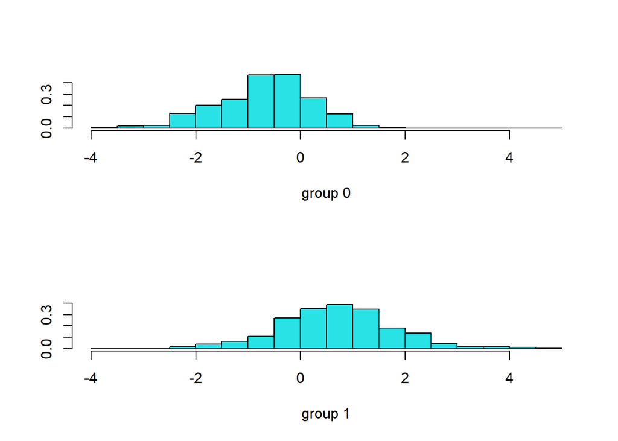

```r
plot(lda.fit)
```

```r
lda.pred <- predict(lda.fit, norm_test)
lda.class <- lda.pred$class
```

```r
#tablica kontyngencji
table(lda.class, norm_test$AMI)
```

```
##
## lda.class  0  1
##         0 67 28
##         1 15 52
```

```r
#dokładność modelu
mean(lda.class == norm_test$AMI)
```

```
## [1] 0.7345679
```

Tablice kontyngencji: Model LDA prawidłowo zakwalifikował 119 obserwacji, a błędnie 43. Dokładność modelu LDA po normalizacji wynosi: 0.7346.

```r
# ROC
# Uzyskiwanie prawdopodobieństw dla klasy "1" (pozytywnej)
lda.prob <- lda.pred$posterior[, 2]
dane.test.num <- as.numeric(as.character(test$AMI))
# Dane do wykresu
roc_obj <- roc( dane.test.num, lda.prob )
```

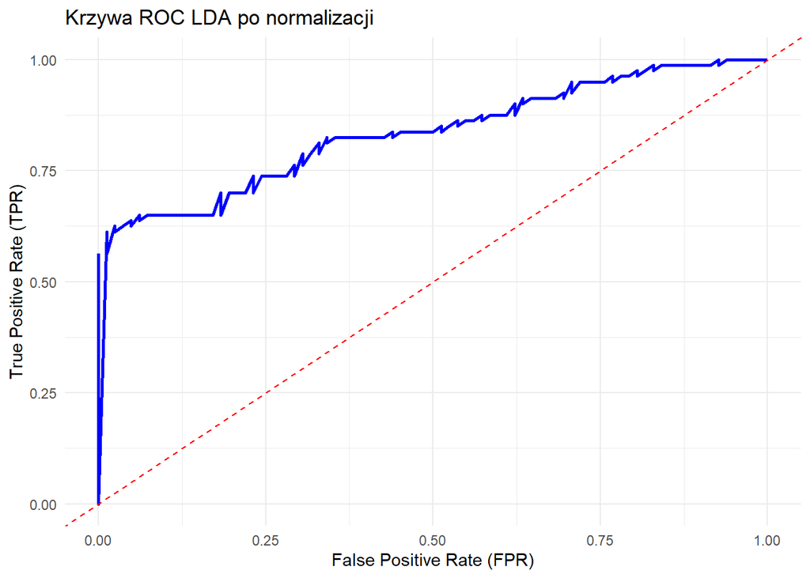

```r
roc_data <- data.frame(
  TPR = roc_obj$sensitivities,   # True Positive Rate
  FPR = 1 - roc_obj$specificities # False Positive Rate
)

# Rysowanie wykresu
ggplot(roc_data, aes(x = FPR, y = TPR)) +
  geom_line(color = "blue", linewidth = 1) +
  geom_abline(linetype = "dashed", color = "red") +
  labs(title = "Krzywa ROC LDA po normalizacji", x = "False Positive Rate (FPR)", y = "True Positive Rate (TPR)") +
  theme_minimal()
```

Obliczamy AUC (pole pod wykresem ROC LDA po normalizacji).

```r
# Obliczenie AUC
auc_value_LDA_N <- auc(roc_obj)
print(paste("AUC (pole pod wykresem ROC LDA po normalizacji):", auc_value_LDA_N))
```

```
## [1] "AUC (pole pod wykresem ROC LDA po normalizacji): 0.835213414634146"
```

Tworzymy model QDA.

```r
#QDA
qda.fit <- qda(AMI ~ ., data = norm_train)
qda.fit
```

```
## Call:
## qda(AMI ~ ., data = norm_train)
##
## Prior probabilities of groups:
##         0         1
## 0.5152625 0.4847375
##
## Group means:
##        SEX1      AGE      WBC      RBC      HGB        LY         MO
## 0 0.5071090 58.36730 1.795007 2.575563 15.28238 0.8588342 -0.5290158
## 1 0.6599496 60.42317 2.078663 2.577758 15.42186 0.9573313 -0.3381031
```

```r
qda.pred <- predict(qda.fit, norm_test)
qda.class <- qda.pred$class
```

```r
#tablica kontyngencji
table(qda.class, norm_test$AMI)
```

```
##
## qda.class  0  1
##         0 73 25
##         1  9 55
```

```r
#dokładność modelu
mean(qda.class == norm_test$AMI)
```

```
## [1] 0.7901235
```

Model QDA zakwalifikował 128 obserwacji, a błędnie 34. Natomiast dokładność modelu QDA po normalizacji wynosi: 0.7901. Tworzymy krzywą ROC

```r
# ROC
# Uzyskiwanie prawdopodobieństw dla klasy "1" (pozytywnej)
qda.prob <- qda.pred$posterior[, 2]
dane.test.num <- as.numeric(as.character(test$AMI))
# Dane do wykresu
roc_obj <- roc( dane.test.num, qda.prob )
```

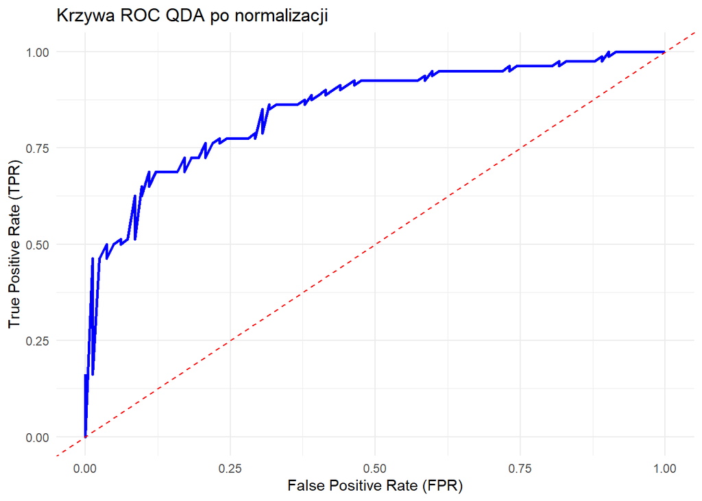

```r
roc_data <- data.frame(
  TPR = roc_obj$sensitivities,   # True Positive Rate
  FPR = 1 - roc_obj$specificities # False Positive Rate
)

# Rysowanie wykresu
ggplot(roc_data, aes(x = FPR, y = TPR)) +
  geom_line(color = "blue", linewidth = 1) +
  geom_abline(linetype = "dashed", color = "red") +
  labs(title = "Krzywa ROC QDA po normalizacji", x = "False Positive Rate (FPR)", y = "True Positive Rate (TPR)") +
  theme_minimal()
```

Obliczamy AUC (pole pod wykresem ROC QDA po normalizacji).

```r
# Obliczenie AUC
auc_value_QDA_N <- auc(roc_obj)
print(paste("AUC (pole pod wykresem ROC QDA po normalizacji):", auc_value_QDA_N))
```

```
## [1] "AUC (pole pod wykresem ROC QDA po normalizacji): 0.851676829268293"
```

## 3.4. Bagging

Kolejnym modelem jest *bagging*. Budujemy model.

```r
#BAGGING
bag.ami <- randomForest(AMI ~ . , data = dane, subset = train_sample,  mtry = 7, importance = TRUE)
bag.ami
```

```
##
## Call:
##  randomForest(formula = AMI ~ ., data = dane, mtry = 7, importance = TRUE,      subset = train_sample)
##                Type of random forest: classification
##                      Number of trees: 500
## No. of variables tried at each split: 7
##
##         OOB estimate of  error rate: 20.39%
## Confusion matrix:
##     0   1 class.error
## 0 358  64   0.1516588
## 1 103 294   0.2594458
```

```r
yhat.bag <- predict(bag.ami, newdata = dane[-train_sample,])
dane.test <- dane[-train_sample, "AMI"]
```

Tworzymy tablicę kontyngencji.

```r
#tablica kontyngencji
table(yhat.bag, dane.test)
```

```
##         dane.test
## yhat.bag  0  1
##        0 71 21
##        1 11 59
```

```r
#dokładność modelu
mean(yhat.bag == dane.test)
```

```
## [1] 0.8024691
```

Model prawidłowo kwalifikował 130 obserwacji, a nieprawidłowo 32.Dokładność wynosi: 0.8025.

```r
# ROC
yhat.bag_prob <- predict(bag.ami, newdata = dane[-train_sample,], type = "prob")[,2]
dane.test.num <- as.numeric(as.character(dane.test))
# Dane do wykresu
roc_obj <- roc(dane.test.num, yhat.bag_prob)
```

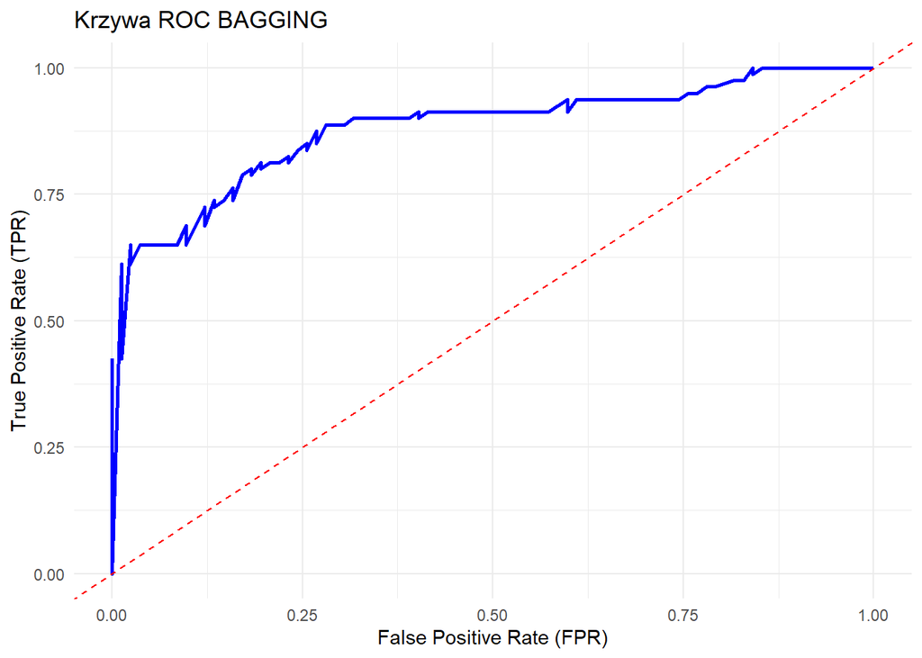

```r
roc_data <- data.frame(
  TPR = roc_obj$sensitivities,   # True Positive Rate
  FPR = 1 - roc_obj$specificities # False Positive Rate
)

# Rysowanie wykresu
ggplot(roc_data, aes(x = FPR, y = TPR)) +
  geom_line(color = "blue", linewidth = 1) +
  geom_abline(linetype = "dashed", color = "red") +
  labs(title = "Krzywa ROC BAGGING", x = "False Positive Rate (FPR)", y = "True Positive Rate (TPR)") +
  theme_minimal()
```

Obliczamy AUC (pole pod wykresem ROC BAGGING).

```r
# Obliczenie AUC
auc_value_BAG <- auc(roc_obj)
print(paste("AUC (pole pod wykresem ROC BAGGING):", auc_value_BAG))
```

```
## [1] "AUC (pole pod wykresem ROC BAGGING): 0.88094512195122"
```

## 3.5. Random forest

Następnym modelem jest *random forest*, czyli lasy losowe. Budujemy model.

```r
#RANDOM FOREST
rf.ami<- randomForest(AMI ~ ., data = dane, subset = train_sample,
                          mtry = 3, importance = TRUE)
yhat.rf <- predict(rf.ami, newdata = dane[-train_sample,])
```

Tworzymy tablicę kontyngencji.

```r
#tablica kontyngencji
table(yhat.rf, dane.test)
```

```
##        dane.test
## yhat.rf  0  1
##       0 70 20
##       1 12 60
```

```r
#dokładność modelu
mean(yhat.rf == dane.test)
```

```
## [1] 0.8024691
```

Prawidłowo zakwalifikował 130 obserwacji, a nieprawidłowo 32. Dokładność modelu wynosi: 0.8024.

Za pomocą funkcji importance() otrzymamy wykres, który pokaże jak bardzo zmienna jest znacząca dla modelu.

```r
#wykres przedstawiający jak bardzo zmienne są znaczące
importance(rf.ami)
```

```
##             0         1 MeanDecreaseAccuracy MeanDecreaseGini
## SEX  10.53550 12.022229             14.91837          7.25010
## AGE  17.58851 12.900995             21.10882         38.70973
## WBC 103.34843 53.580140            103.46246        155.21289
## RBC  24.01164  6.932218             25.07400         45.90586
## HGB  20.57756  0.937193             19.12350         36.29820
## LY   36.46943  7.858854             35.94963         65.26245
## MO   23.24298  9.036475             26.19013         60.04650
```

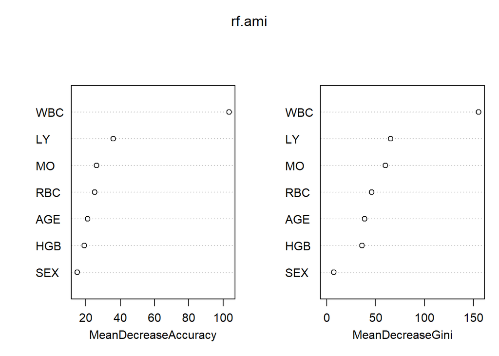

```r
varImpPlot(rf.ami)
```

Jak pokazują miary MDA i MDG, najbardziej znaczącą zmienną jest WBC, kolejne to LY oraz MO, natomiast najmniejszy wpływ mają zmienne HGB i SEX.

Tworzymy krzywą ROC.

```r
#ROC
yhat.rf_prob <- predict(rf.ami, newdata = dane[-train_sample,], type = "prob")[,2]
dane.test.num <- as.numeric(as.character(dane.test))
# Dane do wykresu
roc_obj <- roc(dane.test.num, yhat.rf_prob)
```

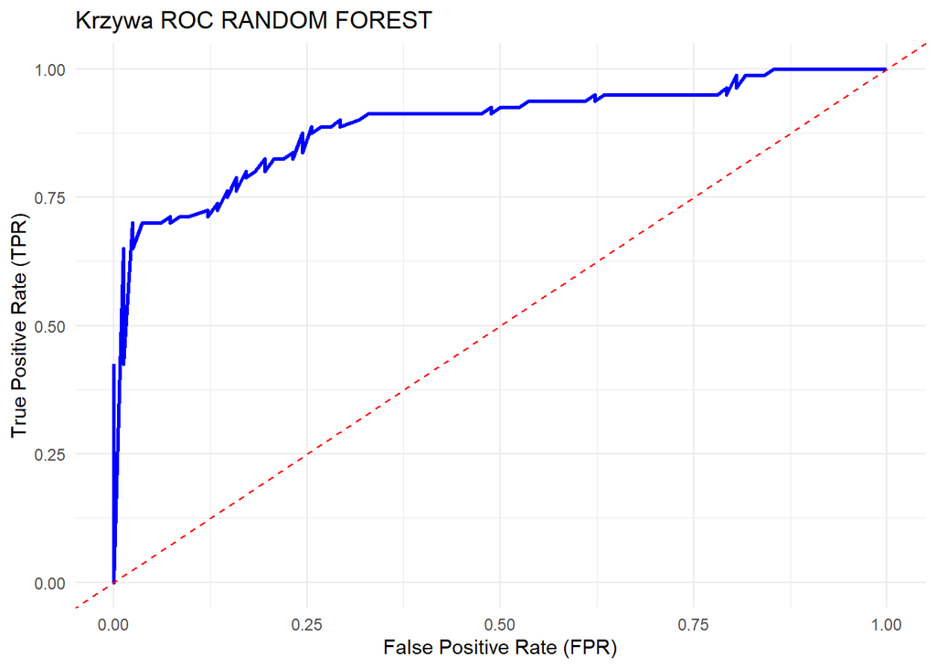

```r
roc_data <- data.frame(
  TPR = roc_obj$sensitivities,   # True Positive Rate
  FPR = 1 - roc_obj$specificities # False Positive Rate
)

# Rysowanie wykresu
ggplot(roc_data, aes(x = FPR, y = TPR)) +
  geom_line(color = "blue", linewidth = 1) +
  geom_abline(linetype = "dashed", color = "red") +
  labs(title = "Krzywa ROC RANDOM FOREST", x = "False Positive Rate (FPR)", y = "True Positive Rate (TPR)") +
  theme_minimal()
```

Obliczamy AUC (pole pod wykresem ROC RANDOM FOREST).

```r
# Obliczenie AUC
auc_value_RF <- auc(roc_obj)
print(paste("AUC (pole pod wykresem ROC RANDOM FOREST):", auc_value_RF))
```

```
## [1] "AUC (pole pod wykresem ROC RANDOM FOREST): 0.893292682926829"
```

## 3.6. Boosting

Kolejnym modelem jest *boosting*. Budujemy model.

```r
dane_ami_num <- dane
dane_ami_num$AMI <- as.numeric(as.character(dane$AMI))
dane.test.num <- as.numeric(as.character(dane.test))

boost.ami <- gbm(AMI ~ . , data = dane_ami_num[
  train_sample,],
  distribution = "bernoulli", n.trees = 5000,
  interaction.depth = 4)
```

Sprawdzimy, które zmienne są dla modelu kluczowe.

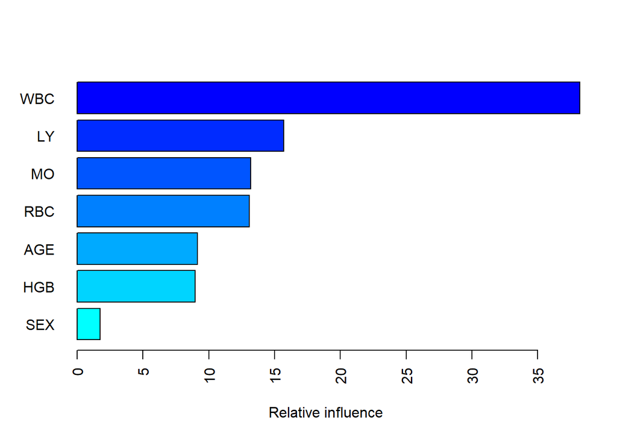

```
##     var   rel.inf
## WBC WBC 38.198952
## LY   LY 15.694342
## MO   MO 13.180422
## RBC RBC 13.070413
## AGE AGE  9.156562
## HGB HGB  8.963481
## SEX SEX  1.735829
```

```r
#wykres pokazuje znaczenie zmiennych dla modelu
summary(boost.ami, las = 2)
```

Z modelu boost.ami wynika, że najbardziej wpływową zmienna jest WBC, następne w kolejności to LY oraz MO.

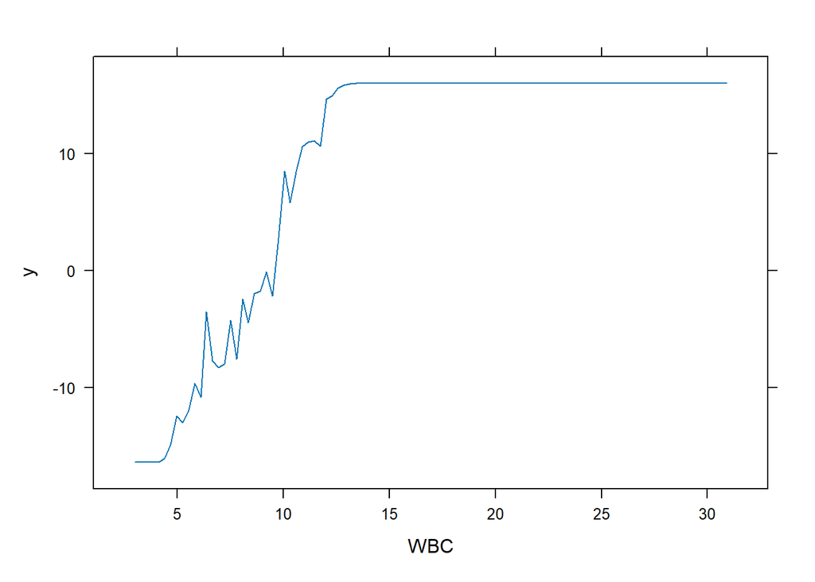

```r
#gęstości brzegowe dla zmiennych
plot(boost.ami, i = "WBC")
```

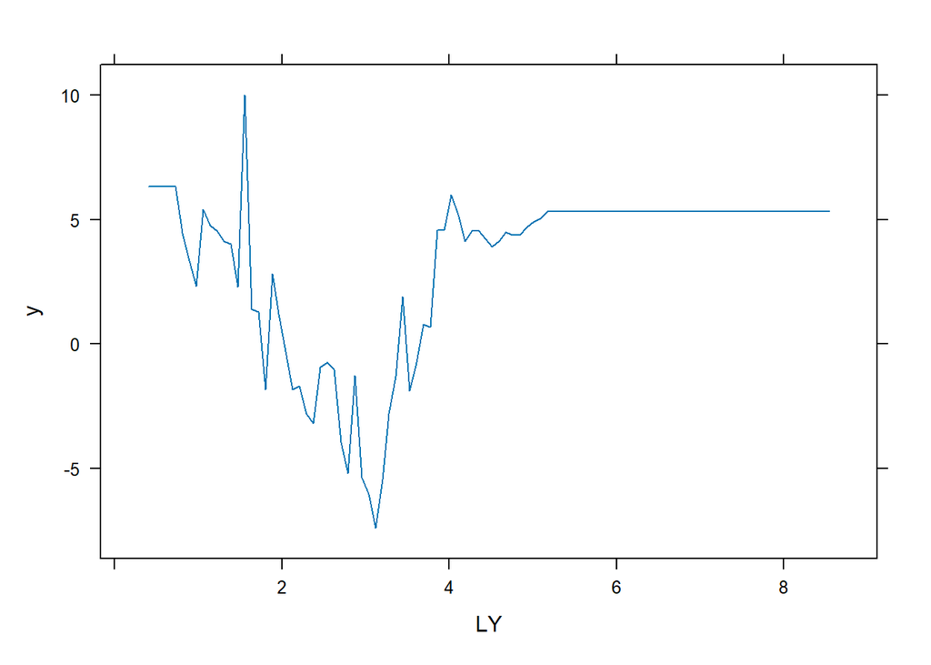

```r
plot(boost.ami, i = "LY")
```

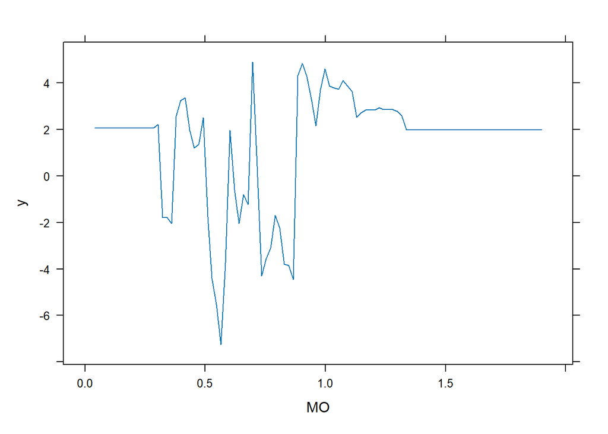

```r
plot(boost.ami, i = "MO")
```

```r
yhat.boost <- predict(boost.ami, newdata = dane_ami_num[-train_sample, ], n.trees = 5000)
```

```r
# Przekształcenie logitowej wartości na prawdopodobieństwa
yhat.boost.prob <- 1 / (1 + exp(-yhat.boost))

# Konwersja prawdopodobieństw na klasy (0 lub 1)
yhat.boost.class <- ifelse(yhat.boost.prob >= 0.5, 1, 0)
```

Tworzymy tablice.

```r
#tablica kontyngencji
table(yhat.boost.class, dane.test)
```

```
##                 dane.test
## yhat.boost.class  0  1
##                0 67 15
##                1 15 65
```

```r
#dokładność modelu
mean(yhat.boost.class == dane.test)
```

```
## [1] 0.8148148
```

Prawidłowo zakwalifikował 132 obserwacji, a nieprawidłowo 30. Dokładność modelu wynosi: 0.8148. Tworzymy krzywą ROC.

```r
# ROC
# Dane do wykresu
roc_obj <- roc(dane.test.num, yhat.boost.prob)
```

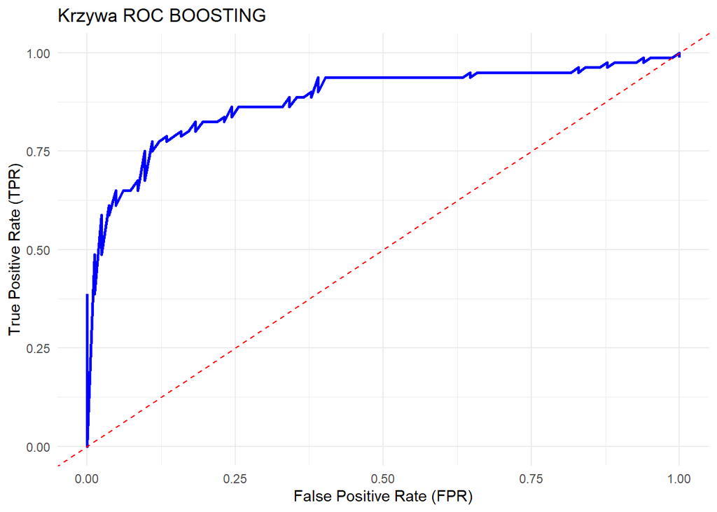

```r
roc_data <- data.frame(
  TPR = roc_obj$sensitivities,   # True Positive Rate
  FPR = 1 - roc_obj$specificities # False Positive Rate
)

# Rysowanie wykresu
ggplot(roc_data, aes(x = FPR, y = TPR)) +
  geom_line(color = "blue", linewidth = 1) +
  geom_abline(linetype = "dashed", color = "red") +
  labs(title = "Krzywa ROC BOOSTING", x = "False Positive Rate (FPR)", y = "True Positive Rate (TPR)") +
  theme_minimal()
```

Obliczamy AUC (pole pod wykresem ROC BOOSTING).

```r
# Obliczenie AUC
auc_value_BOOS <- auc(roc_obj)
print(paste("AUC (pole pod wykresem ROC BOOSTING):", auc_value_BOOS))
```

```
## [1] "AUC (pole pod wykresem ROC BOOSTING): 0.882621951219512"
```

## 3.7. Bayesian additive regression tree

Następnym modelem jest *Bayesian additive regression tree* (BART).

```r
x <- dane[, 2:8]
dane.ami <- dane[, "AMI"]
dane.ami <- as.numeric(as.character(dane.ami))
xtrain <- x[train_sample, ]
dane.ami.train <- dane.ami[train_sample]
xtest <- x[-train_sample, ]
dane.ami.test <- dane.ami[-train_sample]
```

Sprawdzimy dwie funkcje logitową lbart() oraz probitową pbart().

```r
# Funkcja lbart z domyślnymi parametrami
bartfit <- lbart(xtrain, dane.ami.train, x.test = xtest)
```

[output not shown]

```r
# Sprawdzamy na danych testowych:
yhat.bart<- bartfit$prob.test.mean
yhat.bart.class <- ifelse(yhat.bart > 0.5, 1, 0)  # Klasyfikacja binarna
```

```r
#tablica kontyngencji
table(yhat.bart.class, dane.test)
```

```
##                dane.test
## yhat.bart.class  0  1
##               0 73 27
##               1  9 53
```

```r
#dokładność modelu
mean(yhat.bart.class == dane.test)
```

```
## [1] 0.7777778
```

Model z funkcją lbart() prawidłowo zakwalifikował 126 obserwacji, błędnie zakwalifikowane obserwacje to 36. Dokładność modelu z użyciem funkcji lbart() wynosi: 0.7778.

```r
ord <- order(bartfit$varcount.mean, decreasing = T)
bartfit$varcount.mean[ord]
```

```
##    WBC     LY    AGE    HGB   SEX2   SEX1     MO    RBC
## 35.986 31.963 30.345 28.791 28.784 27.886 25.076 21.179
```

```r
# Im większa wartość, tym bardziej istotna była dana zmienna w predykcji modelu
```

Najważniejsze zmienne wskazane przez model to: WBC, LY i AGE.

Obliczamy krzywą ROC.

```r
# ROC
# Dane do wykresu
roc_obj <- roc(dane.ami.test, yhat.bart)
```

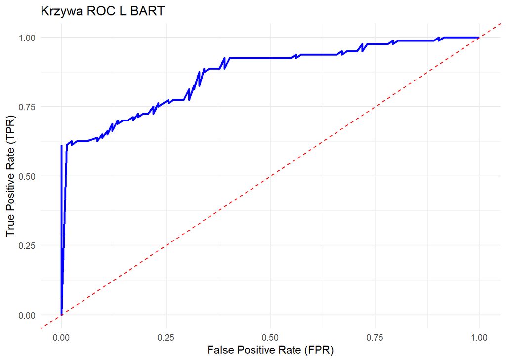

```r
roc_data <- data.frame(
  TPR = roc_obj$sensitivities,   # True Positive Rate
  FPR = 1 - roc_obj$specificities # False Positive Rate
)

# Rysowanie wykresu
ggplot(roc_data, aes(x = FPR, y = TPR)) +
  geom_line(color = "blue", linewidth = 1) +
  geom_abline(linetype = "dashed", color = "red") +
  labs(title = "Krzywa ROC L BART", x = "False Positive Rate (FPR)", y = "True Positive Rate (TPR)") +
  theme_minimal()
```

Obliczamy AUC (pole pod wykresem ROC L BART).

```r
# Obliczenie AUC
auc_value_BART_L <- auc(roc_obj)
print(paste("AUC (pole pod wykresem ROC L BART):", auc_value_BART_L))
```

```
## [1] "AUC (pole pod wykresem ROC L BART): 0.869969512195122"
```

Teraz do tworzenia modelu wykorzystamy funkcję probitową.

```r
# Funkcja pbart z domyślnymi parametrami
bartfit <- pbart(xtrain, dane.ami.train, x.test = xtest)
```

[output not shown]

```r
yhat.bart<- bartfit$prob.test.mean
yhat.bart.class <- ifelse(yhat.bart > 0.5, 1, 0)  # Klasyfikacja binarna
```

```r
#tablica kontyngencji
table(yhat.bart.class, dane.test)
```

```
##                dane.test
## yhat.bart.class  0  1
##               0 72 25
##               1 10 55
```

```r
#dokładność modelu
mean(yhat.bart.class == dane.test)
```

```
## [1] 0.7839506
```

Model z funkcją pbart() prawidłowo zakwalifikował 127 obserwacji, a błędnie 35. Dokładność modelu wynosi 0.7840.

```r
ord <- order(bartfit$varcount.mean, decreasing = T)
bartfit$varcount.mean[ord]
```

```
##    WBC     LY    AGE     MO   SEX1   SEX2    RBC    HGB
## 10.663  9.100  7.488  7.331  6.419  6.044  5.535  5.525
```

Ten model również wskazał, że najbardziej znaczące zmienne to: WBC, LY i AGE.

Tworzymy krzywą ROC.

```r
# ROC
# Dane do wykresu
roc_obj <- roc(dane.ami.test, yhat.bart)
```

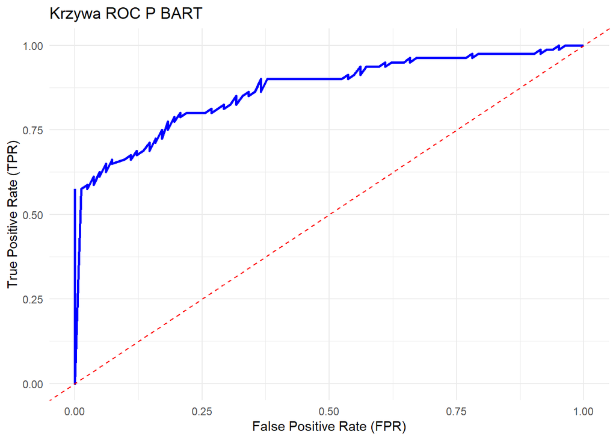

```r
roc_data <- data.frame(
  TPR = roc_obj$sensitivities,   # True Positive Rate
  FPR = 1 - roc_obj$specificities # False Positive Rate
)

# Rysowanie wykresu
ggplot(roc_data, aes(x = FPR, y = TPR)) +
  geom_line(color = "blue", linewidth = 1) +
  geom_abline(linetype = "dashed", color = "red") +
  labs(title = "Krzywa ROC P BART", x = "False Positive Rate (FPR)", y = "True Positive Rate (TPR)") +
  theme_minimal()
```

Obliczamy AUC (pole pod wykresem ROC P BART).

```r
# Obliczenie AUC
auc_value_BART_P <- auc(roc_obj)
print(paste("AUC (pole pod wykresem ROC P BART):", auc_value_BART_P))
```

```
## [1] "AUC (pole pod wykresem ROC P BART): 0.870731707317073"
```

Jak widzimy po tablicach kontyngencji i AUC, model dają bardzo podobne wyniki.

## 3.8. XGBoost

Ostatnim modelem jest *XGBoost*. Przekształcamy dane, aby były odpowiednie do modelu.

```r
# Wczytujemy dane:
# 1. Konwersja danych
x <- dane
x[] <- lapply(x, function(col) {
  if (is.factor(col) || is.character(col)) {
    as.numeric(as.character(col))
  } else {
    as.numeric(col)
  }
})
x <- as.matrix(x)
y.ami <- as.numeric(as.character(dane[, "AMI"]))

# 2. Podział na zbiory
xtrain <- x[train_sample, ]
y.ami.train <- y.ami[train_sample]
xtest <- x[-train_sample, ]
y.ami.test <- y.ami[-train_sample]

data_train <- list(data = xtrain[,2:8], label = y.ami.train)
data_test <- list(data = xtest[,2:8], label = y.ami.test)

# DMatrix dla zbioru treningowego
dtrain <- xgb.DMatrix(data = data_train$data, label = data_train$label)
# DMatrix dla zbioru testowego
dtest <- xgb.DMatrix(data = data_test$data, label = data_test$label)
```

```r
# szukanie optymalnej wartości parametru nrounds
watchlist <- list(train=dtrain, test=dtest)
model <- xgb.train(data = dtrain, max.depth = 3, watchlist = watchlist,
                   nrounds = 200)
bstSparse <- xgboost(data = data_train$data, label = data_train$label,
                     max.depth = 6, eta = 0.1, nthread = 2, nrounds = 50,
                     objective = "binary:logistic", eval_metric = "error")
bstDMatrix <- xgboost(data = dtrain,
                      max.depth = 2, eta = 0.1, nthread = 2, nrounds = 50,
                      objective = "binary:logistic", eval_metric = "error")
y_pred <- predict(bstDMatrix, newdata = dtest)
y_pred_class <- ifelse(y_pred > 0.5, 1, 0)
```

```r
#tablica kontyngencji
table(y_pred_class, y.ami.test)
```

```
##             y.ami.test
## y_pred_class  0  1
##            0 78 25
##            1  4 55
```

```r
#dokładność modelu
mean(y_pred_class == y.ami.test)
```

```
## [1] 0.8209877
```

```r
# ROC
# Dane do wykresu
roc_obj <- roc(y.ami.test, y_pred)
```

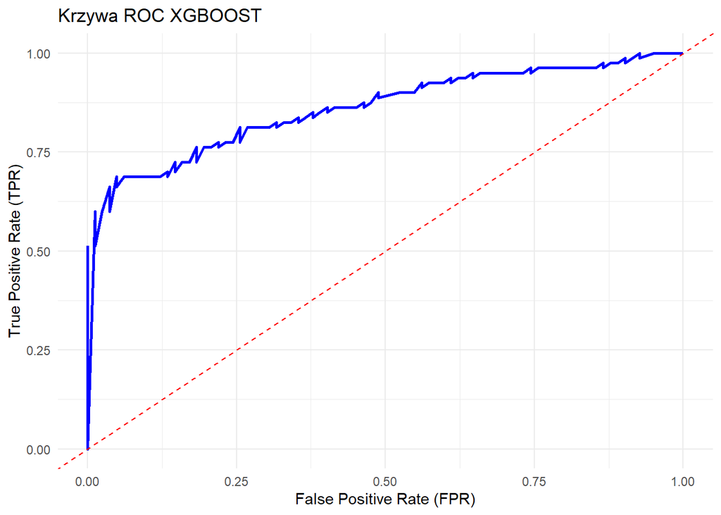

```r
roc_data <- data.frame(
  TPR = roc_obj$sensitivities,   # True Positive Rate
  FPR = 1 - roc_obj$specificities # False Positive Rate
)

# Rysowanie wykresu
ggplot(roc_data, aes(x = FPR, y = TPR)) +
  geom_line(color = "blue", linewidth = 1) +
  geom_abline(linetype = "dashed", color = "red") +
  labs(title = "Krzywa ROC XGBOOST", x = "False Positive Rate (FPR)", y = "True Positive Rate (TPR)") +
  theme_minimal()
```

Obliczamy AUC (pole pod wykresem ROC XGBOOST).

```r
# Obliczenie AUC
auc_value_XGB <- auc(roc_obj)
print(paste("AUC (pole pod wykresem ROC XGBOOST):", auc_value_XGB))
```

```
## [1] "AUC (pole pod wykresem ROC XGBOOST): 0.86219512195122"
```

# 4. Posumowanie i porównanie modeli

Przejdźmy teraz do porównania modeli. W tabeli zostały przedstawione nazwy modeli i obliczony dla nich AUC.

```r
podsumowanie <- data.frame(
  Model = c('LDA', 'QDA', 'LDA (norm)', 'QDA (norm)',   'BAGGING', 'RANDOM FOREST', 'BOOSTING', 'BART LOGIT', 'BART PROBIT', 'XGBOOST'),
  AUC = c(auc_value_LDA, auc_value_QDA, auc_value_LDA_N, auc_value_QDA_N, auc_value_BAG, auc_value_RF, auc_value_BOOS, auc_value_BART_L, auc_value_BART_P, auc_value_XGB)
)

podsumowanie <- podsumowanie[order(-podsumowanie$AUC), ]

knitr::kable(podsumowanie,
             caption = "Porównanie skuteczności modeli klasyfikacyjnych",
             digits = 4,
             col.names = c("Model", "AUC"),
             row.names = FALSE)
```

Porównanie skuteczności modeli klasyfikacyjnych

| Model | AUC |
| --- | --- |
| RANDOM FOREST | 0.8933 |
| BOOSTING | 0.8826 |
| BAGGING | 0.8809 |
| BART PROBIT | 0.8707 |
| BART LOGIT | 0.8700 |
| QDA | 0.8695 |
| XGBOOST | 0.8622 |
| QDA (norm) | 0.8517 |
| LDA | 0.8416 |
| LDA (norm) | 0.8352 |

Po dokładnej analizie miary AUC widzimy, że wszystkie modele osiągają zbliżone wyniki i bardzo dobrze klasyfikują dane do odpowiednich grup. Najniższą wartość wskaźnika odnotowano dla modelu LDA po normalizacji (AUC = 0.8352), co pokazuje, że nawet najsłabszy z modeli radzi sobie poprawnie z tym zbiorem danych. Co ciekawe, zastosowana normalizacja danych pogorszyła skuteczność zarówno modelu LDA, jak i QDA.